# Tekentoets

# 1 Toepassing

Gebruik de *tekentoets* om de mediaan van een steekproef te vergelijken met een bekende mediaan of norm in een populatie.[^1] Deze toets wordt gebruikt als er niet aan de assumpties is voldaan bij sterkere toetsen zoals de one sample t-toets en de Wilcoxon signed rank toets. Als de verdeling van de steekproef bij benadering normaal verdeeld is, dan kan de one sample t-toets gebruikt worden om het gemiddelde van een steekproef te vergelijken met een bekend gemiddelde of norm in een populatie. Als de verdeling symmetrisch is, kan de Wilcoxon signed rank toets gebruikt worden om de mediaan van een steekproef te vergelijken met een bekende mediaan of norm in een populatie. De Wilcoxon signed rank toets heeft in dat geval een hoger onderscheidend vermogen[^2].

# 2 Onderwijscasus

De opleidingsdirecteur van de school voor Journalistiek is benieuwd wat alumni verdienen ten opzichte van de gemiddelde Nederlander. Daarom wil zij de jaarinkomens van oud-studenten vergelijken met het mediane jaarinkomen van werknemers in Nederland van €35.200.[^3] Op deze manier vergaart zij meer informatie over het succes op de arbeidsmarkt na de opleiding Journalistiek.

Dit onderzoek vertaalt zich in de volgende combinatie van hypothesen, waarbij de nulhypothese zo geformuleerd is dat er geen effect of verschil is en de alternatieve hypothese zo geformuleerd is dat er wel een effect of verschil is.

*H<sub>0</sub>*: De mediaan van het jaarinkomen van alumni Journalistiek is gelijk aan €35.200, het mediane jaarinkomen in Nederland.

*H<sub>A</sub>*: De mediaan van het jaarinkomen van alumni Journalistiek is niet gelijk aan €35.200, het mediane jaarinkomen in Nederland.

# 3 Assumpties

Het meetniveau van de variabele is continu.[^4]

# 4 Uitvoering

Er is data ingeladen met jaarlijkse bruto inkomens van alumni van de school voor Journalistiek genaamd `Jaarlijks_inkomen`. De directeur wil kijken hoe haar oud-studenten scoren ten opzichte van het mediane jaarinkomen in Nederland.

## 4.1 De data bekijken

Gebruik `head()` en `tail()` om de data te bekijken.

```r
## Eerste 6 observaties
head(Jaarlijks_inkomen)
##   Studentnummer Inkomen
## 1       4466713   44047
## 2       4000958   66004
## 3       4136967   49442
## 4       4090719   42890
## 5       4414229   59478
## 6       4191784   61857

## Laatste 6 observaties
tail(Jaarlijks_inkomen)
##    Studentnummer Inkomen
## 24       4061987   34349
## 25       4401307   32022
## 26       4179848   66667
## 27       4392861   42721
## 28       4425075   43956
## 29       4016485   38288
```

Inspecteer de data met `mean()`, `sd()`, `median()` en `length()` om meer inzicht te krijgen in de data.

```r
mean(Jaarlijks_inkomen$Inkomen)
## [1] 50902.48
sd(Jaarlijks_inkomen$Inkomen)
## [1] 14511.16
median(Jaarlijks_inkomen$Inkomen)
## [1] 49234
length(Jaarlijks_inkomen$Inkomen)
## [1] 29
```

Het gemiddelde jaarinkomen van de alumni is €50902,48 met een standaardafwijking van €14511,16 (*n* = 29). De mediaan van het inkomen is €49234.

## 4.2 De data visualiseren

Visualiseer de data om een goed beeld van de jaarinkomens van de alumni te krijgen. Geef de verdeling van de data weer in een histogram[^5]. Focus bij het analyseren van een histogram op de symmetrie van de verdeling, de hoeveelheid toppen (modaliteit) en mogelijke uitbijters.[^6]<sup>,</sup>[^7]

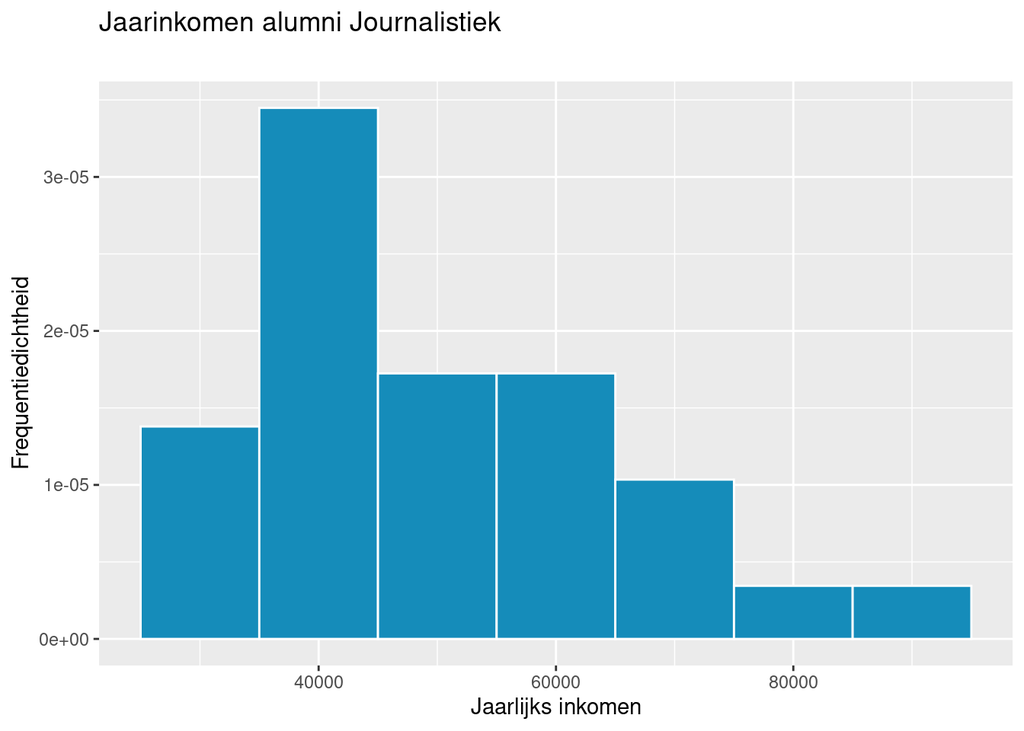

```r
## Histogram met ggplot2
library(ggplot2)

ggplot(Jaarlijks_inkomen,
       aes(x = Inkomen)) +
  geom_histogram(aes(y = ..density..),
                 binwidth = 10000,
                 color = "white",
                 fill = "#158CBA") +
  #geom_density(alpha = .2, adjust = 1) +
  ylab("Frequentiedichtheid") +
  xlab("Jaarlijks inkomen") +
scale_x_continuous(labels = as.character(seq(20000, 100000, 20000)),
                   breaks = seq(20000, 100000, 20000)) +
labs(title = "Jaarinkomen alumni Journalistiek",
     subtitle = "")
```

De verdeling heeft één top en geen uitbijters. De histogram laat echter ook zien dat de verdeling een langere staart aan de rechterkant heeft en dus enigszins afwijkt van de (symmetrische) normaalverdeling. Aangezien de verdeling niet symmetrisch is, kan de Wilcoxon signed rank toets niet gebruikt worden om een hypothese over de mediaan te toetsen.